# Seventh Week: Generalized Linear Models

Murder or suicide

benyamin jami al ahmadi 94105282

2018-04-28 02:41:22

> با توجه به سوالات مرگ و میر در آمریکا به سوالات زیر پاسخ دهید.

۱. از میان متغیرهای داده مرگ و میر یک زیرمجموعه ایی بدون حشو در نظر بگیرید. ماتریس همبستگی متغیرهای مختلف را به دست آورده و سپس رسم نمایید. علاوه بر این نمودار پراکنش متغیرهای انتخاب شده را همزمان نسبت به هم رسم نمایید.

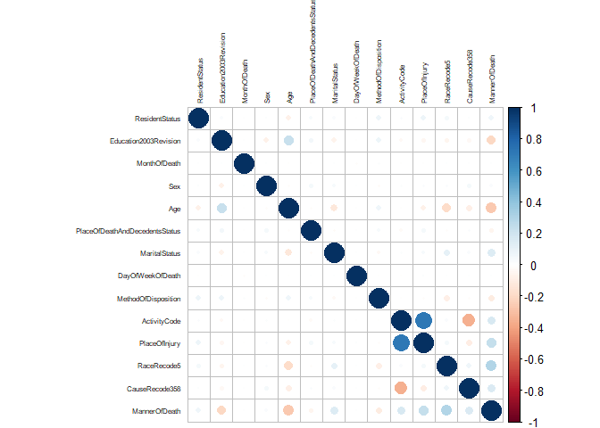

```r
data1 = murder_suicide %>% filter(EducationReportingFlag == 1, AgeType == 1) %>% select(ResidentStatus,Education2003Revision,MonthOfDeath,Sex,Age,PlaceOfDeathAndDecedentsStatus,MaritalStatus,DayOfWeekOfDeath,MethodOfDisposition,ActivityCode,PlaceOfInjury,RaceRecode5,CauseRecode358,MannerOfDeath,MethodOfDisposition,PlaceOfInjury)
data1 %>% mutate_if(is.character, factor) %>% mutate_if(is.factor, as.numeric) -> data1
data1$MannerOfDeath <- ifelse(data1$MannerOfDeath==3,1,0)
data1 %>% select_if(is.numeric) %>% cor(use="complete.obs") %>% corrplot(tl.cex = 0.5,tl.col = "black")
```

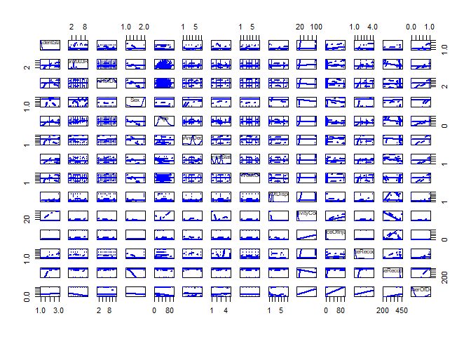

```r
data1 %>% filter(row_number() < 1000) %>% scatterplotMatrix(cex = 0.05)
```

۲. اثر هر یک از متغیرهای جنسیت، نژاد،آموزش، سن و نحوه تدفین را بر مرگ یا خودکشی ارزیابی کنید.

```r
data1 %>% group_by(Sex,MannerOfDeath) %>% summarise(n = n()) %>% tidyr::spread(MannerOfDeath,n) %>% .[,-1] %>% as.matrix() %>% chisq.test()
```

```
##
##  Pearson's Chi-squared test with Yates' continuity correction
##
## data:  .
## X-squared = 34.524, df = 1, p-value = 4.211e-09
```

```r
data1 %>% group_by(RaceRecode5,MannerOfDeath) %>% summarise(n = n()) %>% tidyr::spread(MannerOfDeath,n) %>% .[,-1] %>% as.matrix() %>% chisq.test()
```

```
##
##  Pearson's Chi-squared test
##
## data:  .
## X-squared = 13768, df = 3, p-value < 2.2e-16
```

```r
data1 %>% group_by(Education2003Revision,MannerOfDeath) %>% summarise(n = n()) %>% tidyr::spread(MannerOfDeath,n) %>% .[,-1] %>% as.matrix() %>% chisq.test()
```

```
##
##  Pearson's Chi-squared test
##
## data:  .
## X-squared = 3315.8, df = 8, p-value < 2.2e-16
```

```r
data1 %>% mutate(MannerOfDeath = ifelse(MannerOfDeath == 2,0,1)) %>% glm(formula = MannerOfDeath~Age,family = binomial(link = 'logit')) %>% summary.glm()
```

```
##
## Call:
## glm(formula = MannerOfDeath ~ Age, family = binomial(link = "logit"),
##     data = .)
##
## Deviance Residuals:
##       Min         1Q     Median         3Q        Max
## 2.409e-06  2.409e-06  2.409e-06  2.409e-06  2.409e-06
##
## Coefficients:
##              Estimate Std. Error z value Pr(>|z|)
## (Intercept) 2.657e+01  3.694e+03   0.007    0.994
## Age         1.940e-11  7.630e+01   0.000    1.000
##
## (Dispersion parameter for binomial family taken to be 1)
##
##     Null deviance: 0.0000e+00  on 54114  degrees of freedom
## Residual deviance: 3.1395e-07  on 54113  degrees of freedom
## AIC: 4
##
## Number of Fisher Scoring iterations: 25
```

```r
data1 %>% group_by(MethodOfDisposition,MannerOfDeath) %>% summarise(n = n()) %>% tidyr::spread(MannerOfDeath,n) %>% .[,-1] %>% as.matrix() %>% chisq.test()
```

```
##
##  Pearson's Chi-squared test
##
## data:  .
## X-squared = 4387.9, df = 6, p-value < 2.2e-16
```

۳. با استفاده از مدل رگرسیون لاجستیک یک مدل به داده ها برازش دهید و سپس آن را نقص یابی کنید.

```r
model1<-glm(data = data1 %>% mutate(MannerOfDeath = as.factor(MannerOfDeath)),formula = MannerOfDeath ~ ., family = binomial(link = 'logit'))
summary.glm(model1)
```

```
##
## Call:
## glm(formula = MannerOfDeath ~ ., family = binomial(link = "logit"),
##     data = data1 %>% mutate(MannerOfDeath = as.factor(MannerOfDeath)))
##
## Deviance Residuals:
##     Min       1Q   Median       3Q      Max
## -8.4904  -0.4930  -0.3390   0.3715   8.4904
##
## Coefficients:
##                                  Estimate Std. Error z value Pr(>|z|)
## (Intercept)                    -1.471e+02  1.557e+00 -94.467  < 2e-16 ***
## ResidentStatus                  5.286e-03  2.263e-02   0.234    0.815
## Education2003Revision          -1.791e-01  8.668e-03 -20.666  < 2e-16 ***
## MonthOfDeath                    2.681e-03  3.768e-03   0.711    0.477
## Sex                            -2.192e-01  3.151e-02  -6.958 3.46e-12 ***
## Age                            -1.941e-02  7.682e-04 -25.271  < 2e-16 ***
## PlaceOfDeathAndDecedentsStatus -9.942e-02  6.144e-03 -16.181  < 2e-16 ***
## MaritalStatus                   1.487e-01  1.416e-02  10.504  < 2e-16 ***
## DayOfWeekOfDeath                2.517e-03  6.342e-03   0.397    0.691
## MethodOfDisposition            -1.045e-01  1.307e-02  -7.993 1.31e-15 ***
## ActivityCode                    6.816e-01  8.915e-03  76.461  < 2e-16 ***
## PlaceOfInjury                   1.341e-01  1.818e-03  73.761  < 2e-16 ***
## RaceRecode5                     5.573e-01  1.794e-02  31.056  < 2e-16 ***
## CauseRecode358                  3.268e-01  3.458e-03  94.518  < 2e-16 ***
## ---
## Signif. codes:  0 '***' 0.001 '**' 0.01 '*' 0.05 '.' 0.1 ' ' 1
##
## (Dispersion parameter for binomial family taken to be 1)
##
##     Null deviance: 64075  on 54114  degrees of freedom
## Residual deviance: 32858  on 54101  degrees of freedom
## AIC: 32886
##
## Number of Fisher Scoring iterations: 10
```

```r
data1[,-c(1,3,8)] -> data3
model2<-glm(data = data3 %>% mutate(MannerOfDeath = as.factor(MannerOfDeath)),formula = MannerOfDeath ~ ., family = binomial(link = 'logit'))
summary.glm(model2)
```

```
##
## Call:
## glm(formula = MannerOfDeath ~ ., family = binomial(link = "logit"),
##     data = data3 %>% mutate(MannerOfDeath = as.factor(MannerOfDeath)))
##
## Deviance Residuals:
##     Min       1Q   Median       3Q      Max
## -8.4904  -0.4929  -0.3394   0.3715   8.4904
##
## Coefficients:
##                                  Estimate Std. Error z value Pr(>|z|)
## (Intercept)                    -1.471e+02  1.555e+00 -94.619  < 2e-16 ***
## Education2003Revision          -1.790e-01  8.648e-03 -20.697  < 2e-16 ***
## Sex                            -2.191e-01  3.151e-02  -6.954 3.54e-12 ***
## Age                            -1.943e-02  7.672e-04 -25.322  < 2e-16 ***
## PlaceOfDeathAndDecedentsStatus -9.945e-02  6.145e-03 -16.185  < 2e-16 ***
## MaritalStatus                   1.489e-01  1.416e-02  10.516  < 2e-16 ***
## MethodOfDisposition            -1.040e-01  1.300e-02  -7.999 1.25e-15 ***
## ActivityCode                    6.818e-01  8.905e-03  76.560  < 2e-16 ***
## PlaceOfInjury                   1.341e-01  1.806e-03  74.259  < 2e-16 ***
## RaceRecode5                     5.575e-01  1.794e-02  31.072  < 2e-16 ***
## CauseRecode358                  3.269e-01  3.449e-03  94.768  < 2e-16 ***
## ---
## Signif. codes:  0 '***' 0.001 '**' 0.01 '*' 0.05 '.' 0.1 ' ' 1
##
## (Dispersion parameter for binomial family taken to be 1)
##
##     Null deviance: 64075  on 54114  degrees of freedom
## Residual deviance: 32855  on 54104  degrees of freedom
## AIC: 32877
##
## Number of Fisher Scoring iterations: 8
```

۴. با استفاده از سه نمودار خروجی مدل را نسبت به داده واقعی ارزیابی کنید.

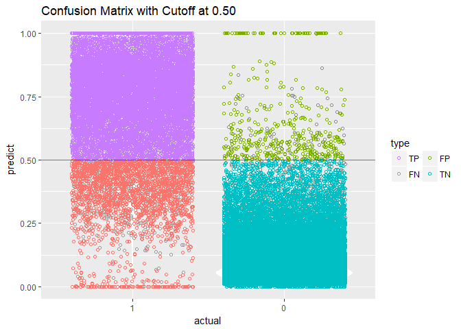

```r
data3$fit <- predict(object = model2, data3,type = "response")
cm_info = ConfusionMatrixInfo(data = data3, predict = "fit",actual = "MannerOfDeath", cutoff = 0.5)
cm_info$plot
```

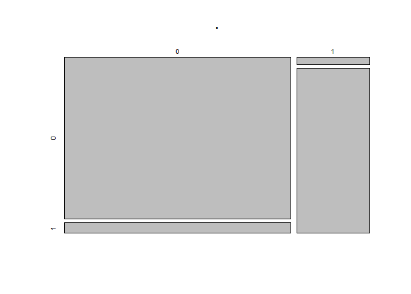

```r
data3$pred <- ifelse(data3$fit>0.5,1,0)
table(data3$pred,data3$MannerOfDeath) %>% plot()
```

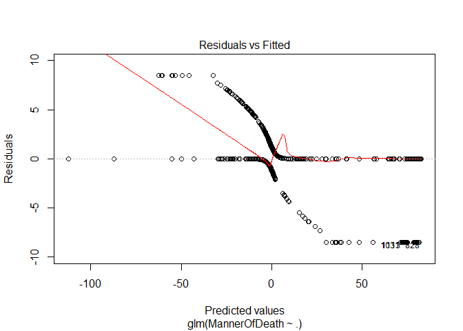

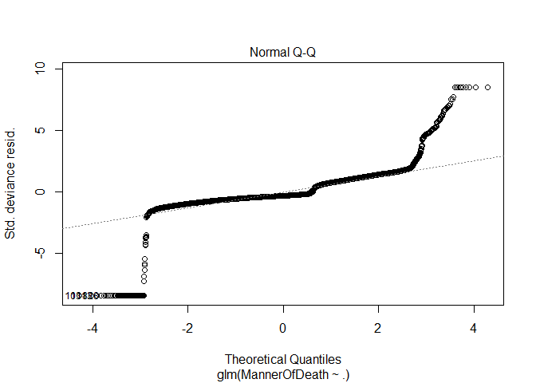

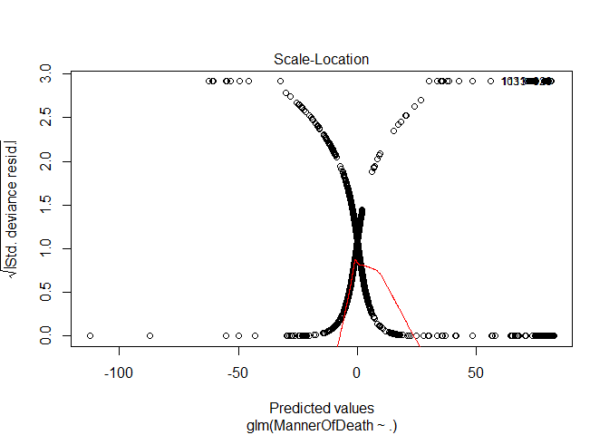

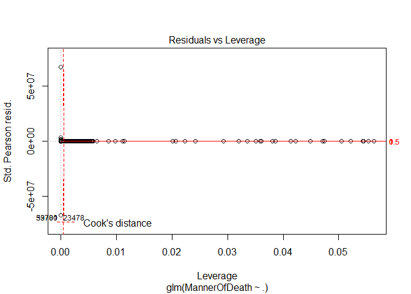

```r
plot(model2)
```

۵. ابتدا ۲۰ درصد داده را به صورت تصادفی به عنوان تست در نظر بگیرید. مدل را با استفاده از ۸۰ درصد باقی مانده برازش دهید. با استفاده از پارامتر قطع ۰.۵ نتایج را برای داده تست پیش بینی کنید. سپس کمیت های زیر را محاسبه کنید.

- P: positive samples
- N: negative samples
- TP: true positive TP (eqv. with hit)
- TN: true negative (eqv. with correct rejection)
- FP: false positive (eqv. with false alarm, Type I error)
- FN: false negative (eqv. with miss, Type II error)
- Accuracy (ACC) ACC = (TP+TN)/(P+T)
- False positive rate (FPR): 1- TN/N
- True positive rate (TPR): TP/P

مشابه آنچه در کلاس گفته شد نمایشی از چهار کمیت TN, TP,FP,FN به همراه داده ها رسم نمایید.

```r
set.seed(100)  # setting seed to reproduce results of random sampling
trainingRowIndex <- sample(1:nrow(data3), 0.8*nrow(data3))  # row indices for training data
trainingData <- data3[trainingRowIndex, ]  # model training data
testData  <- data3[-trainingRowIndex, ]   # test data
testmodel <- glm(data = trainingData %>% mutate(MannerOfDeath = as.factor(MannerOfDeath)),formula = MannerOfDeath ~ ., family = binomial(link = 'logit'))
testData$fit <- predict(object = testmodel, testData,type = "response")
testData$pred <- ifelse(testData$fit > 0.5,1,0)
P = sum(testData$pred == 1)
P
```

```
## [1] 2932
```

```r
N = sum(testData$pred == 0)
N
```

```
## [1] 7891
```

```r
TP = sum(testData$pred == 1 & testData$MannerOfDeath == 1)
TP
```

```
## [1] 2820
```

```r
TN = sum(testData$pred == 0 & testData$MannerOfDeath == 0)
TN
```

```
## [1] 7797
```

```r
FP = sum(testData$pred == 1 & testData$MannerOfDeath == 0)
FP
```

```
## [1] 112
```

```r
FN = sum(testData$pred == 0 & testData$MannerOfDeath == 1)
FN
```

```
## [1] 94
```

```r
ACC <- (TP+TN)/(P+N)
ACC
```

```
## [1] 0.9809665
```

```r
FPR <- 1- TN/N
FPR
```

```
## [1] 0.01191231
```

```r
TPR<- TP/P
TPR
```

```
## [1] 0.9618008
```

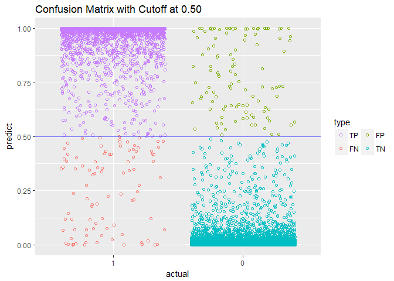

```r
cm_info = ConfusionMatrixInfo(data = testData, predict = "fit",actual = "MannerOfDeath", cutoff = .5)

cm_info$plot
```

۶. نمودار صحت مدل (accuracy) را بر حسب مقادیر مختلف قطع برای داده تست رسم نمایید. کدام پارامتر قطع بالاترین صحت را در پیش بینی داراست؟

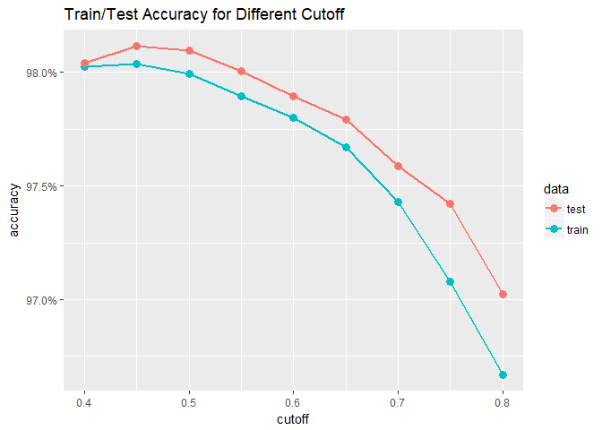

```r
trainingData$fit <- predict(object = testmodel, trainingData,type = "response")
trainingData$pred <- ifelse(trainingData$fit > 0.5,1,0)
accuracy_info = AccuracyCutoffInfo( train = trainingData, test = testData,
                                     predict = "fit", actual = "MannerOfDeath" )
accuracy_info$plot
```

```r
accs = c()
i = 0
maxacc = 0;
acc = 0
for(i in seq(0, to = 1, by = 0.001)){
  testData$pred <- ifelse(testData$fit > i,1,0)
  P = sum(testData$pred == 1)
  N = sum(testData$pred == 0)
  TP = sum(testData$pred == 1 & testData$MannerOfDeath == 1)
  TN = sum(testData$pred == 0 & testData$MannerOfDeath == 0)
  FP = sum(testData$pred == 1 & testData$MannerOfDeath == 0)
  FN = sum(testData$pred == 0 & testData$MannerOfDeath == 1)
  ACC <- (TP+TN)/(P+N)
  accs = c(accs,ACC)
  #print(paste("cut off: " , as.character(i) , " ACC:" , as.character(ACC)))
  if(ACC > maxacc){
    maxacc = ACC
    acc = i
  }
}
acc
```

```
## [1] 0.471
```

```r
maxacc
```

```
## [1] 0.9816132
```

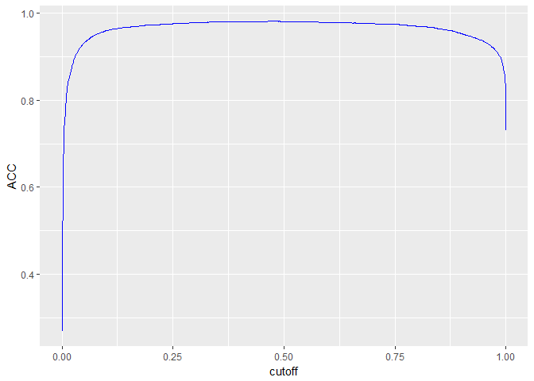

```r
temp = data_frame(cutoff = seq(0,to=1,by=0.001),ACC = accs)
ggplot(temp) + geom_line(aes(x = cutoff,y=ACC),color = "blue")
```

۷. نمودار ROC را برای داده های قسمت قبل رسم نمایید. همچنین نقطه مربوط به بهترین پارامتر قطع را مشخص نمایید.

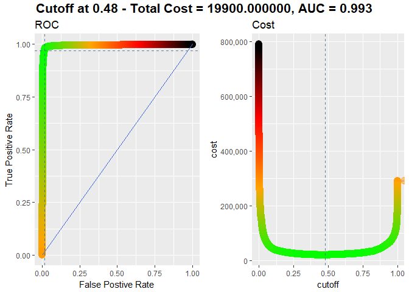

```r
cost_fp = 100;cost_fn = 100
roc_info = ROCInfo( data = cm_info$data, predict = "predict",
                     actual = "actual", cost.fp = cost_fp, cost.fn = cost_fn )
grid.draw(roc_info$plot)
```

۸. با قرار دادن کمیت nfolds = 5 و با استفاده از H20 مدل مساله را بسازید و نتیجه حاصل را ارزیابی کنید.

```r
h2o.init()
```

[output not shown]

```r
data8 <- as.h2o(data3 %>% mutate(MannerOfDeath = as.factor(MannerOfDeath)))
model8 = h2o.glm(training_frame = data8,y = "MannerOfDeath",x = data3 %>% colnames() %>% .[-12],family = "binomial",nfold=5)
summary(model8)
```

```
## Model Details:
## ==============
##
## H2OBinomialModel: glm
## Model Key:  GLM_model_R_1524861746121_109
## GLM Model: summary
##     family  link                               regularization
## 1 binomial logit Elastic Net (alpha = 0.5, lambda = 7.68E-4 )
##   number_of_predictors_total number_of_active_predictors
## 1                         11                          11
##   number_of_iterations             training_frame
## 1                    5 file2e5caf23aa7_sid_a4cf_2
##
## H2OBinomialMetrics: glm
## ** Reported on training data. **
##
## MSE:  0.05252033
## RMSE:  0.2291731
## LogLoss:  0.2118503
## Mean Per-Class Error:  0.08984691
## AUC:  0.9179709
## Gini:  0.8359418
## R^2:  0.7389211
## Residual Deviance:  22928.56
## AIC:  22952.56
##
## Confusion Matrix (vertical: actual; across: predicted) for F1-optimal threshold:
##            0     1    Error         Rate
## 0      38416   600 0.015378   =600/39016
## 1       2481 12618 0.164316  =2481/15099
## Totals 40897 13218 0.056934  =3081/54115
##
## Maximum Metrics: Maximum metrics at their respective thresholds
##                         metric threshold    value idx
## 1                       max f1  0.158691 0.891196 190
## 2                       max f2  0.118653 0.858561 205
## 3                 max f0point5  0.900209 0.938054  97
## 4                 max accuracy  0.310792 0.943121 165
## 5                max precision  0.933010 0.980742  83
## 6                   max recall  0.008824 1.000000 393
```

[output cut: 88 more lines]

```
## =================================================
##
## Standardized Coefficient Magnitudes: standardized coefficient magnitudes
##                             names coefficients sign
## 1                            pred     2.857250  POS
## 2                     RaceRecode5     0.473600  NEG
## 3             MethodOfDisposition     0.115521  POS
## 4  PlaceOfDeathAndDecedentsStatus     0.113912  POS
## 5                  CauseRecode358     0.098503  NEG
## 6                             Sex     0.084946  NEG
## 7                   MaritalStatus     0.066549  NEG
## 8                             Age     0.063626  POS
## 9           Education2003Revision     0.042667  POS
## 10                   ActivityCode     0.022637  NEG
## 11                  PlaceOfInjury     0.022074  POS
```

با توجه به نتایج حداکثر دقت 0.943121 میباشد.

۹. آیا ما میتوانیم سرویسی به قضات ارایه کنیم تا با استفاده از اطلاعات مرگ بتوانند موارد مشکوک به قتل را از خودکشی تفکیک دهند؟

با توجه به اینه حداکثر دقت در این مدل0.943121میباشد میتوان گف که میتواند کمک خوبی در دادگاه دهد و در موارد خاص رای دادگاه را به حقیقت نزدیک تر کند اما نمیتوان به از این مدل به صورت کاملا مستقیم استفاده کرد.